# Lockman SWIRE master catalogue

## Preparation of Pan-STARRS1 - 3pi Steradian Survey (3SS) data

This catalogue comes from `dmu0_PanSTARRS1-3SS`.

The Pan-STARRS1-3SS catalogue provides for each band an aperture magnitude defined as “In PS1, an 'optimal' aperture radius is determined based on the local PSF. The wings of the same analytic PSF are then used to extrapolate the flux measured inside this aperture to a 'total' flux.”

The observations used for the catalogue where done between 2010 and 2015 ([ref](https://confluence.stsci.edu/display/PANSTARRS/PS1+Image+data+products)).

**TODO**: Check if the detection flag can be used to know in which bands an object was detected to construct the coverage maps.

**TODO**: Check for stellarity.

```python
from herschelhelp_internal import git_version
print("This notebook was run with herschelhelp_internal version: \n{}".format(git_version()))
```

```
This notebook was run with herschelhelp_internal version:
44f1ae0 (Thu Nov 30 18:27:54 2017 +0000)
```

```python
%matplotlib inline
#%config InlineBackend.figure_format = 'svg'

import matplotlib.pyplot as plt
plt.rc('figure', figsize=(10, 6))

from collections import OrderedDict
import os

from astropy import units as u
from astropy.coordinates import SkyCoord
from astropy.table import Column, Table
import numpy as np

from herschelhelp_internal.flagging import  gaia_flag_column
from herschelhelp_internal.masterlist import nb_astcor_diag_plot, remove_duplicates
from herschelhelp_internal.utils import astrometric_correction, mag_to_flux
```

```python
OUT_DIR =  os.environ.get('TMP_DIR', "./data_tmp")
try:
    os.makedirs(OUT_DIR)
except FileExistsError:
    pass

RA_COL = "ps1_ra"
DEC_COL = "ps1_dec"
```

## I - Column selection

```python
imported_columns = OrderedDict({
        "objID": "ps1_id",
        "raMean": "ps1_ra",
        "decMean": "ps1_dec",
        "gFApMag": "m_ap_gpc1_g",
        "gFApMagErr": "merr_ap_gpc1_g",
        "gFKronMag": "m_gpc1_g",
        "gFKronMagErr": "merr_gpc1_g",
        "rFApMag": "m_ap_gpc1_r",
        "rFApMagErr": "merr_ap_gpc1_r",
        "rFKronMag": "m_gpc1_r",
        "rFKronMagErr": "merr_gpc1_r",
        "iFApMag": "m_ap_gpc1_i",
        "iFApMagErr": "merr_ap_gpc1_i",
        "iFKronMag": "m_gpc1_i",
        "iFKronMagErr": "merr_gpc1_i",
        "zFApMag": "m_ap_gpc1_z",
        "zFApMagErr": "merr_ap_gpc1_z",
        "zFKronMag": "m_gpc1_z",
        "zFKronMagErr": "merr_gpc1_z",
        "yFApMag": "m_ap_gpc1_y",
        "yFApMagErr": "merr_ap_gpc1_y",
        "yFKronMag": "m_gpc1_y",
        "yFKronMagErr": "merr_gpc1_y"
    })


catalogue = Table.read("../../dmu0/dmu0_PanSTARRS1-3SS/data/PanSTARRS1-3SS_Lockman-SWIRE_v2.fits")[list(imported_columns)]
for column in imported_columns:
    catalogue[column].name = imported_columns[column]

epoch = 2012

# Clean table metadata
catalogue.meta = None
```

```python
# Adding flux and band-flag columns
for col in catalogue.colnames:
    if col.startswith('m_'):

        errcol = "merr{}".format(col[1:])

        # -999 is used for missing values
        catalogue[col][catalogue[col] < -900] = np.nan
        catalogue[errcol][catalogue[errcol] < -900] = np.nan

        flux, error = mag_to_flux(np.array(catalogue[col]), np.array(catalogue[errcol]))

        # Fluxes are added in µJy
        catalogue.add_column(Column(flux * 1.e6, name="f{}".format(col[1:])))
        catalogue.add_column(Column(error * 1.e6, name="f{}".format(errcol[1:])))

        # Band-flag column
        if "ap" not in col:
            catalogue.add_column(Column(np.zeros(len(catalogue), dtype=bool), name="flag{}".format(col[1:])))

# TODO: Set to True the flag columns for fluxes that should not be used for SED fitting.
```

```python
catalogue[:10].show_in_notebook()
```

<Table masked=True length=10>

| idx | ps1_id | ps1_ra | ps1_dec | m_ap_gpc1_g | merr_ap_gpc1_g | m_gpc1_g | merr_gpc1_g | m_ap_gpc1_r | merr_ap_gpc1_r | m_gpc1_r | merr_gpc1_r | m_ap_gpc1_i | merr_ap_gpc1_i | m_gpc1_i | merr_gpc1_i | m_ap_gpc1_z | merr_ap_gpc1_z | m_gpc1_z | merr_gpc1_z | m_ap_gpc1_y | merr_ap_gpc1_y | m_gpc1_y | merr_gpc1_y | f_ap_gpc1_g | ferr_ap_gpc1_g | f_gpc1_g | ferr_gpc1_g | flag_gpc1_g | f_ap_gpc1_r | … |
| --- | --- | --- | --- | --- | --- | --- | --- | --- | --- | --- | --- | --- | --- | --- | --- | --- | --- | --- | --- | --- | --- | --- | --- | --- | --- | --- | --- | --- | --- | --- |
| 0 | 174791587823544922 | 158.78246416 | 55.66184088 | 20.9363994598 | 0.0599370002747 | 21.0373001099 | 0.054552000016 | 19.8181991577 | 0.0530960001051 | 19.7028999329 | 0.0271390005946 | 19.2402000427 | 0.0165509991348 | 19.1396007538 | 0.019551999867 | 19.1051998138 | 0.0129009997472 | 18.9197998047 | 0.0304589997977 | 18.7576999664 | 0.0463580004871 | 18.7509002686 | 0.0390789993107 | 15.3264021227 | 0.846078968548 | 13.9662546398 | 0.701723973095 | False | 42.9259916658 | … |
| 1 | 174791586597581621 | 158.65980707 | 55.65906984 | 19.0060997009 | 0.011698000133 | 19.0746994019 | 0.0153360003605 | 18.0837001801 | 0.002623999957 | 18.1653003693 | 0.00371300010011 | 17.6625003815 | 0.00379300001077 | 17.7318000793 | 0.00412400020286 | 17.5076999664 | 0.00479099992663 | 17.5851993561 | 0.00792600028217 | 17.3913993835 | 0.0123049998656 | 17.5184993744 | 0.0132769998163 | 90.6901498778 | 0.977118917732 | 85.1373717859 | 1.20256353125 | False | 212.089871013 | … |
| 2 | 174791585782383763 | 158.57821102 | 55.66084822 | 21.0494003296 | 0.0928269997239 | 21.1278991699 | 0.0873359963298 | 19.8346004486 | 0.0233679991215 | 19.9416007996 | 0.0194669999182 | 18.4265003204 | 0.0114310001954 | 18.4799995422 | 0.0104400003329 | 17.8208007812 | 0.00906699988991 | 17.9174995422 | 0.00762100005522 | 17.5356998444 | 0.0206099990755 | 17.7000007629 | 0.0220320001245 | 13.8114688469 | 1.18083675318 | 12.8481421233 | 1.03349716847 | False | 42.2824185121 | … |
| 3 | 174791586080155691 | 158.60820076 | 55.66248994 | 21.8899002075 | 0.199130997062 | 22.3173999786 | 0.464352995157 | nan | nan | nan | nan | 24.8262004852 | 2.21530008316 | 23.0011005402 | 0.667774021626 | 22.2628993988 | 0.613909006119 | 21.5063991547 | 0.588376998901 | nan | nan | 20.7576999664 | 0.571124970913 | 6.3685405292 | 1.16803125828 | 4.29575998806 | 1.83723174026 | False | nan | … |
| 4 | 174791586394167110 | 158.63896216 | 55.6634777 | 22.6138000488 | 0.240042001009 | 22.8495998383 | 0.153946995735 | 24.464799881 | 1.28269004822 | 23.4951992035 | 0.680122971535 | 21.8348007202 | 0.166409000754 | 21.8859996796 | 0.0913389995694 | 22.1233997345 | 0.417003005743 | 22.6156005859 | 1.21698999405 | 21.2931003571 | 0.39752599597 | 22.2264995575 | 2.63347005844 | 3.26948975227 | 0.72284120118 | 2.63123758894 | 0.373084290739 | False | 0.594401706519 | … |
| 5 | 174791587096447727 | 158.70969677 | 55.66414796 | 20.0228004456 | 0.0372739993036 | 20.1189994812 | 0.0335620008409 | 18.9850997925 | 0.0157399997115 | 19.0541000366 | 0.0198470000178 | 18.4908008575 | 0.0102479998022 | 18.5638008118 | 0.0111239999533 | 18.2808990479 | 0.00906299985945 | 18.3784008026 | 0.0103850001469 | 18.0921993256 | 0.0417880006135 | 18.3048992157 | 0.04725600034 | 35.5532921678 | 1.22056663644 | 32.538700726 | 1.00582802373 | False | 92.4613186735 | … |
| 6 | 174791588777865495 | 158.87781778 | 55.66236012 | 22.8883991241 | 0.201737999916 | 22.5368003845 | 0.162127003074 | 22.2287998199 | 0.127969995141 | 22.1739997864 | 0.116806998849 | 20.6874008179 | 0.0372800007463 | 20.8458003998 | 0.0385849997401 | 20.0587997437 | 0.0421690009534 | 20.1746997833 | 0.0401739999652 | 20.103099823 | 0.151113003492 | 20.1592998505 | 0.161295995116 | 2.53886933626 | 0.471741128003 | 3.50977960655 | 0.524096043372 | False | 4.66101040061 | … |
| 7 | 174791586897306712 | 158.68979131 | 55.66331749 | 19.7087001801 | 0.0332639999688 | 19.7649993896 | 0.0296849999577 | 18.9020996094 | 0.00643000006676 | 18.9599990845 | 0.0087280003354 | 18.5648994446 | 0.00691699981689 | 18.6259994507 | 0.0105750001967 | 18.4232006073 | 0.0100600002334 | 18.5009002686 | 0.0145089998841 | 18.2290992737 | 0.0207870006561 | 18.3164997101 | 0.0433540008962 | 47.4810077513 | 1.454688748 | 45.081695797 | 1.23257392722 | False | 99.806805691 | … |
| 8 | 174791587360317921 | 158.735997 | 55.66434947 | 22.9622993469 | 0.506309986115 | 23.1291999817 | 0.311774998903 | 21.8966999054 | 0.130468994379 | 22.0725002289 | 0.296097010374 | 21.3575000763 | 0.106398001313 | 21.4465999603 | 0.0990919992328 | 21.4890003204 | 0.15636099875 | 21.5545005798 | 0.160959005356 | 21.0293006897 | 0.227841004729 | 21.6907997131 | 0.362470000982 | 2.37181199573 | 1.10604407716 | 2.03385509306 | 0.584032444187 | False | 6.32878056509 | … |
| 9 | 174791588244583776 | 158.82454298 | 55.66087804 | 28.5331001282 | 51.1004981995 | 24.6247005463 | 1.37297999859 | 22.3899002075 | 0.262513011694 | 22.3379993439 | 0.1682099998 | 20.3712997437 | 0.0298420004547 | 20.4664001465 | 0.0342799983919 | 19.5575008392 | 0.0422249995172 | 19.6786003113 | 0.0493469983339 | 19.4657001495 | 0.172241002321 | 19.5461997986 | 0.130023002625 | 0.0140203852971 | 0.659873614318 | 0.513002854302 | 0.64872356203 | False | 4.01827742052 | … |

## II - Removal of duplicated sources

We remove duplicated objects from the input catalogues.

```python
SORT_COLS = ['merr_ap_gpc1_r', 'merr_ap_gpc1_g', 'merr_ap_gpc1_i', 'merr_ap_gpc1_z', 'merr_ap_gpc1_y']
FLAG_NAME = 'ps1_flag_cleaned'

nb_orig_sources = len(catalogue)

catalogue = remove_duplicates(catalogue, RA_COL, DEC_COL,  sort_col=SORT_COLS, flag_name=FLAG_NAME)

nb_sources = len(catalogue)

print("The initial catalogue had {} sources.".format(nb_orig_sources))
print("The cleaned catalogue has {} sources ({} removed).".format(nb_sources, nb_orig_sources - nb_sources))
print("The cleaned catalogue has {} sources flagged as having been cleaned".format(np.sum(catalogue[FLAG_NAME])))
```

```
The initial catalogue had 435078 sources.
The cleaned catalogue has 434925 sources (153 removed).
The cleaned catalogue has 153 sources flagged as having been cleaned
```

## III - Astrometry correction

We match the astrometry to the Gaia one. We limit the Gaia catalogue to sources with a g band flux between the 30th and the 70th percentile. Some quick tests show that this give the lower dispersion in the results.

```python
gaia = Table.read("../../dmu0/dmu0_GAIA/data/GAIA_Lockman-SWIRE.fits")
gaia_coords = SkyCoord(gaia['ra'], gaia['dec'])
```

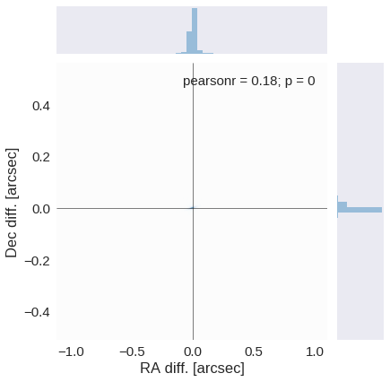

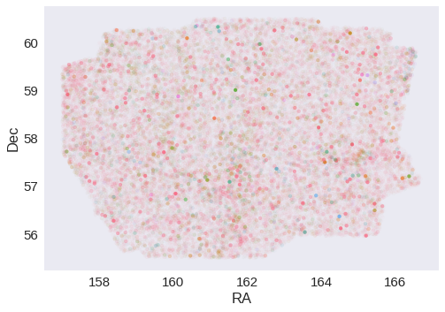

```python
nb_astcor_diag_plot(catalogue[RA_COL], catalogue[DEC_COL],
                    gaia_coords.ra, gaia_coords.dec)
```

```python
delta_ra, delta_dec =  astrometric_correction(
    SkyCoord(catalogue[RA_COL], catalogue[DEC_COL]),
    gaia_coords
)

print("RA correction: {}".format(delta_ra))
print("Dec correction: {}".format(delta_dec))
```

```
RA correction: -0.0006137910020242998 arcsec
Dec correction: -0.00026867304541156045 arcsec
```

```python
catalogue[RA_COL] +=  delta_ra.to(u.deg)
catalogue[DEC_COL] += delta_dec.to(u.deg)
```

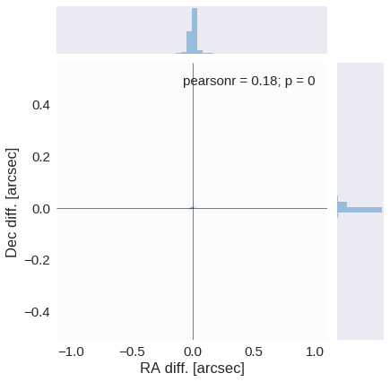

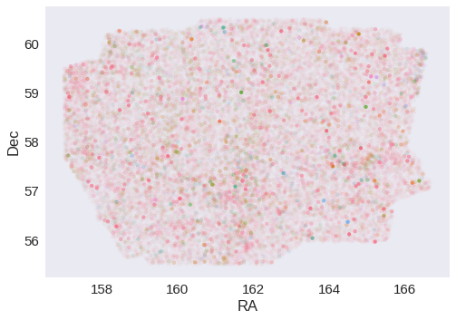

```python
nb_astcor_diag_plot(catalogue[RA_COL], catalogue[DEC_COL],
                    gaia_coords.ra, gaia_coords.dec)
```

## IV - Flagging Gaia objects

```python
catalogue.add_column(
    gaia_flag_column(SkyCoord(catalogue[RA_COL], catalogue[DEC_COL]), epoch, gaia)
)
```

```python
GAIA_FLAG_NAME = "ps1_flag_gaia"

catalogue['flag_gaia'].name = GAIA_FLAG_NAME
print("{} sources flagged.".format(np.sum(catalogue[GAIA_FLAG_NAME] > 0)))
```

```
55984 sources flagged.
```

## V - Flagging objects near bright stars

# VI - Saving to disk

```python
catalogue.write("{}/PS1.fits".format(OUT_DIR), overwrite=True)
```